# EDS 212 Computational Session 3B

Linear algebra basics: scalars, vectors & matrices

In this lesson, we’ll learn about making & working with scalars, vectors and matrices in R.

## Set up

A new workflow! GitHub repo FIRST, then R project.

- Go to github.com (you should already be logged in)
- Click the green ‘New’ or plus sign to create a new repo
- Name it eds212-comp-3b
- Create it **with a ReadMe**
- Click on the green ‘Code’ button and copy https URL
- Go back to RStudio
- Click on New Project > **Version Control** > git > create project (in your EDS 212 folder you’ve created for Day 3). Create the project.
- Tada! Now you have a project set up to go with version control & already connected to a GitHub repo

In your new project:

- Create a new Quarto document
- Save as `r-vectors.qmd`

## Vectors

### Vectors in R

(IN YOUR QUARTO DOC)

Create vectors in R using `c()`. Note that all elements in a vector must be a single class - if numbers and strings are combined, the whole thing will be of class character.

For example:

```r
# Create and store the vector:
marmots <- c("blue", "green", 4, "yellow")

# Return it:
marmots
```

```
## [1] "blue"   "green"  "4"      "yellow"
```

```r
# Check the class:
class(marmots)
```

```
## [1] "character"
```

If all values are numeric, however, it will be stored as a number:

```r
# Create and store the vector:
pika <- c(12.4, 6.8, 2.9, 8.8, 5)

# Return it:
pika
```

```
## [1] 12.4  6.8  2.9  8.8  5.0
```

```r
# Check the class:
class(pika)
```

```
## [1] "numeric"
```

Notice in the vector above, these are class *numeric*. If values should be integers (often the case with count data), you can add an `L` after the value.

```r
# Create the integer vector:
bear <- c(20L, 3L, 5L, 18L, 23L)

# Look at it:
bear
```

```
## [1] 20  3  5 18 23
```

```r
# Check the class:
class(bear)
```

```
## [1] "integer"
```

We learn something important here: even *numbers* can be stored in R in different ways: **floats** are numbers that have decimals (these show up as class “numeric”) and **integers**, numbers without decimals (these show up as class “integer”).

You’ll learn about data representation and other classes of data in EDS 221.

#### Vector addition and subtraction, scalar multiplier, and dot product

You can add or subtract numeric vectors of equal length using basic operations. For example, let’s make two new vectors of length 4, then try adding & subtracting them:

```r
ringtail <- c(4.3, 8.9, 2.6, 7.1)
fox <- c(9.0, 12.5, 5.4, 10.9)

# Addition:
ringtail + fox
```

```
## [1] 13.3 21.4  8.0 18.0
```

```r
# Subtraction:
fox - ringtail
```

```
## [1] 4.7 3.6 2.8 3.8
```

```r
# Scalar multiplier:
100 * ringtail
```

```
## [1] 430 890 260 710
```

```r
# Dot product:
ringtail %*% fox
```

```
##        [,1]
## [1,] 241.38
```

## Matrices

### Matrices in R

A matrix contains data of a single class (usually numbers). Which means that we can think of the contents of a matrix as a single sequence of values, that are constrained (wrapped) to the specified dimensions of the matrix.

For example, let’s say we have 10 values:

```r
# Make a sequence of values from 1 - 10
my_values <- seq(from = 1, to = 10)

# Look at it (always)
my_values
```

```
##  [1]  1  2  3  4  5  6  7  8  9 10
```

Now, we can convert this into a matrix by letting R know how many rows these values should be “wrapped” into (the default is to populate by **column**…see documentation, and *always* look at what you’ve created):

```r
my_matrix <- matrix(data = my_values, nrow = 2, ncol = 5, byrow = TRUE)

# Check it out!
my_matrix
```

```
##      [,1] [,2] [,3] [,4] [,5]
## [1,]    1    2    3    4    5
## [2,]    6    7    8    9   10
```

Try some other variations to make a matrix from `my_values` to test it out. What happens if you don’t have enough elements in the matrix to contain your vector? What happens if your matrix has *more* elements than your vector?

For example:

```r
matrix(data = my_values, nrow = 3, ncol = 4, byrow = TRUE)
```

```
##      [,1] [,2] [,3] [,4]
## [1,]    1    2    3    4
## [2,]    5    6    7    8
## [3,]    9   10    1    2
```

So…**always, always, always** look at what you’ve created.

#### Scalar multiplication, addition and subtraction

Scalar multiplication of a matrix is straightforward: just use the multiply operator (*):

```r
4 * my_matrix
```

```
##      [,1] [,2] [,3] [,4] [,5]
## [1,]    4    8   12   16   20
## [2,]   24   28   32   36   40
```

Addition/subtraction requires matrices of the same dimension. Let’s make another 2x5 matrix:

```r
my_values_2 <- seq(from = 21, to = 30)
my_matrix_2 <- matrix(my_values_2, nrow = 2, byrow = TRUE)

# Check it out:
my_matrix_2
```

```
##      [,1] [,2] [,3] [,4] [,5]
## [1,]   21   22   23   24   25
## [2,]   26   27   28   29   30
```

Add the two matrices:

```r
my_matrix + my_matrix_2
```

```
##      [,1] [,2] [,3] [,4] [,5]
## [1,]   22   24   26   28   30
## [2,]   32   34   36   38   40
```

Similarly for subtraction:

```r
my_matrix_2 - my_matrix
```

```
##      [,1] [,2] [,3] [,4] [,5]
## [1,]   20   20   20   20   20
## [2,]   20   20   20   20   20
```

#### Matrix multiplication

As we saw in lecture, matrix multiplication is a bit more complicated (dot products of rows by columns become elements in the resulting matrix). Here’s a reminder:

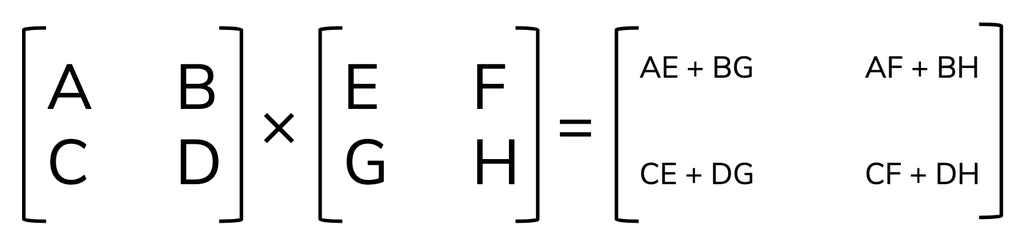

We multiply matrices in R using the same operator as the dot product for vectors: `%*%`

For example:

```r
# Make a couple of 2x2 matrices:
cats <- matrix(data = c(0,4,3,1), nrow = 2, byrow = TRUE)
dogs <- matrix(data = c(6,-3,0,2), nrow = 2, byrow = TRUE)

# Look at them:
cats
```

```
##      [,1] [,2]
## [1,]    0    4
## [2,]    3    1
```

```r
dogs
```

```
##      [,1] [,2]
## [1,]    6   -3
## [2,]    0    2
```

```r
# Matrix multiplication:
cats %*% dogs
```

```
##      [,1] [,2]
## [1,]    0    8
## [2,]   18   -7
```

Confirm that this is correct by doing the matrix multiplication by hand.